# Big Data Analytics

12/03/2020

## Updates

## Register in GitHub Classroom

- Email with instructions will follow.
- Call to register Group Examination Teams!
- If you haven’t formed your team yet, do so within the next two weeks.

## Small Change in the Schedule

1. Introduction: Big Data, Data Economy (Concepts). M: Walkowiak (2016): Chapter 1
2. Programming with Data, R Refresher Course (Concepts/Applied). M: Walkowiak (2016): Chapter 2
3. Computation and Memory (Concepts)
4. Cleaning and Transformation of Big Data (Applied). M: Walkowiak (2016): Chapter 3: p. 74‐118.
5. Aggregation and Visualization (Applied: data tables, ggplot). M: Walkowiak (2016): Chapter 3: p. 118‐127. C: Wickham et al. (2015), Schwabish (2014).
6. *Data Storage, Databases Interaction with R. M: Walkowiak (2016): Chapter 5*
7. *Distributed Systems, MapReduce/Hadoop with R (Concepts/Applied). M: Walkowiak (2016): Chapter 4.*

## R Markdown/Course Repo

- Clone the repository: see README
- R Markdown

## Recap Week 3

## Four strategies of programing with Big Data

1. Use the right building blocks (R-packages)
2. Exploit/avoid R’s idiosyncrasies
3. (Connect to lower-level language, such as C)
4. Use an alternative statistical procedure/estimator

## OLS in R

```r
beta_ols <-
     function(X, y) {

          # compute cross products and inverse
          XXi <- solve(crossprod(X,X))
          Xy <- crossprod(X, y)

          return( XXi  %*% Xy )
     }
```

## Monte Carlo study

- Parameters and pseudo data

```r
# set parameter values
n <- 10000000
p <- 4

# Generate sample based on Monte Carlo
# generate a design matrix (~ our 'dataset') with four variables and 10000 observations
X <- matrix(rnorm(n*p, mean = 10), ncol = p)
# add column for intercept
X <- cbind(rep(1, n), X)
```

## Monte Carlo study

- Model and model output

```r
# MC model
y <- 2 + 1.5*X[,2] + 4*X[,3] - 3.5*X[,4] + 0.5*X[,5] + rnorm(n)
```

## Monte Carlo study

- Performance of OLS

```r
# apply the ols estimator
beta_ols(X, y)
```

```
##            [,1]
## [1,]  2.0031212
## [2,]  1.4998630
## [3,]  3.9997020
## [4,] -3.5000073
## [5,]  0.5001542
```

## The Uluru algorithm as an alternative to OLS

Following Dhillon et al. (2013), we compute \(\hat{\beta}_{Uluru}\):

\[\hat{\beta}_{Uluru}=\hat{\beta}_{FS} + \hat{\beta}_{correct}\], where \[\hat{\beta}_{FS} = (\mathbf{X}_{subs}^\intercal\mathbf{X}_{subs})^{-1}\mathbf{X}_{subs}^{\intercal}\mathbf{y}_{subs}\], and \[\hat{\beta}_{correct}= \frac{n_{subs}}{n_{rem}} \cdot (\mathbf{X}_{subs}^\intercal\mathbf{X}_{subs})^{-1} \mathbf{X}_{rem}^{\intercal}\mathbf{R}_{rem}\], and \[\mathbf{R}_{rem} = \mathbf{Y}_{rem} - \mathbf{X}_{rem} \cdot \hat{\beta}_{FS}\].

## The Uluru algorithm as an alternative to OLS

- Key idea: Compute \((\mathbf{X}^\intercal\mathbf{X})^{-1}\) only on a sub-sample (\(X_{subs}\), etc.)
- If the sample is large enough (which is the case in a Big Data context), the result is approximately the same.

## Uluru algorithm in R (simplified)

```r
# simple version of the Uluru algorithm
beta_uluru <-
     function(X_subs, y_subs, X_rem, y_rem) {

          # compute beta_fs (this is simply OLS applied to the subsample)
          XXi_subs <- solve(crossprod(X_subs, X_subs))
          Xy_subs <- crossprod(X_subs, y_subs)
          b_fs <- XXi_subs  %*% Xy_subs

          # compute \mathbf{R}_{rem}
          R_rem <- y_rem - X_rem %*% b_fs

          # compute \hat{\beta}_{correct}
          b_correct <- (nrow(X_subs)/(nrow(X_rem))) * XXi_subs %*% crossprod(X_rem, R_rem)

          # beta uluru
          return(b_fs + b_correct)
     }
```

## Uluru algorithm in R (simplified)

Test it with the same input as above:

```r
# set size of subsample
n_subs <- 1000
# select subsample and remainder
n_obs <- nrow(X)
X_subs <- X[1L:n_subs,]
y_subs <- y[1L:n_subs]
X_rem <- X[(n_subs+1L):n_obs,]
y_rem <- y[(n_subs+1L):n_obs]

# apply the uluru estimator
beta_uluru(X_subs, y_subs, X_rem, y_rem)
```

```
##            [,1]
## [1,]  2.0021313
## [2,]  1.5014998
## [3,]  3.9990195
## [4,] -3.4970266
## [5,]  0.4964247
```

## Uluru algorithm: Monte Carlo study

```r
# define subsamples
n_subs_sizes <- seq(from = 1000, to = 500000, by=10000)
n_runs <- length(n_subs_sizes)
# compute uluru result, stop time
mc_results <- rep(NA, n_runs)
mc_times <- rep(NA, n_runs)
for (i in 1:n_runs) {
     # set size of subsample
     n_subs <- n_subs_sizes[i]
     # select subsample and remainder
     n_obs <- nrow(X)
     X_subs <- X[1L:n_subs,]
     y_subs <- y[1L:n_subs]
     X_rem <- X[(n_subs+1L):n_obs,]
     y_rem <- y[(n_subs+1L):n_obs]

     mc_results[i] <- beta_uluru(X_subs, y_subs, X_rem, y_rem)[2] # the first element is the intercept
     mc_times[i] <- system.time(beta_uluru(X_subs, y_subs, X_rem, y_rem))[3]

}
```

## Uluru algorithm: Monte Carlo study

```r
# compute ols results and ols time
ols_time <- system.time(beta_ols(X, y))
ols_res <- beta_ols(X, y)[2]
```

## Uluru algorithm: Monte Carlo study

- Visualize comparison with OLS.

```r
# load packages
library(ggplot2)

# prepare data to plot
plotdata <- data.frame(beta1 = mc_results,
                       time_elapsed = mc_times,
                       subs_size = n_subs_sizes)
```

## Uluru algorithm: Monte Carlo study

1. Computation time.

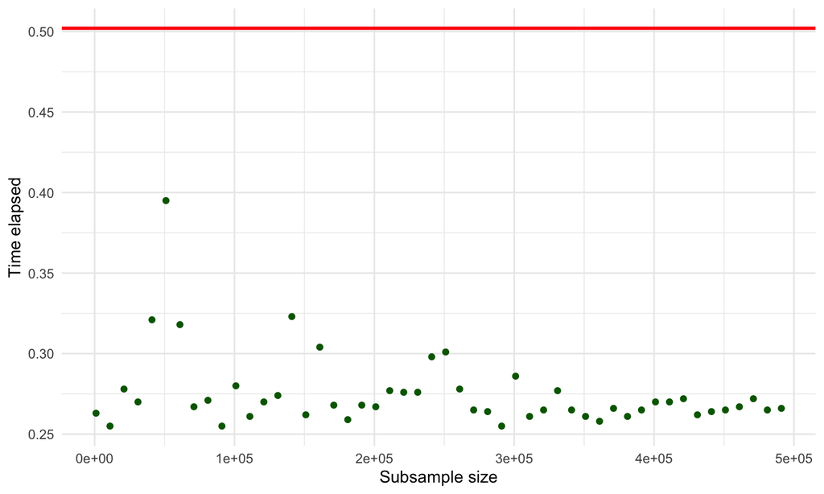

```r
ggplot(plotdata, aes(x = subs_size, y = time_elapsed)) +
     geom_point(color="darkgreen") +
     geom_hline(yintercept = ols_time[3],
                color = "red",
                size = 1) +
     theme_minimal() +
     ylab("Time elapsed") +
     xlab("Subsample size")
```

## Uluru algorithm: Monte Carlo study

1. Precision

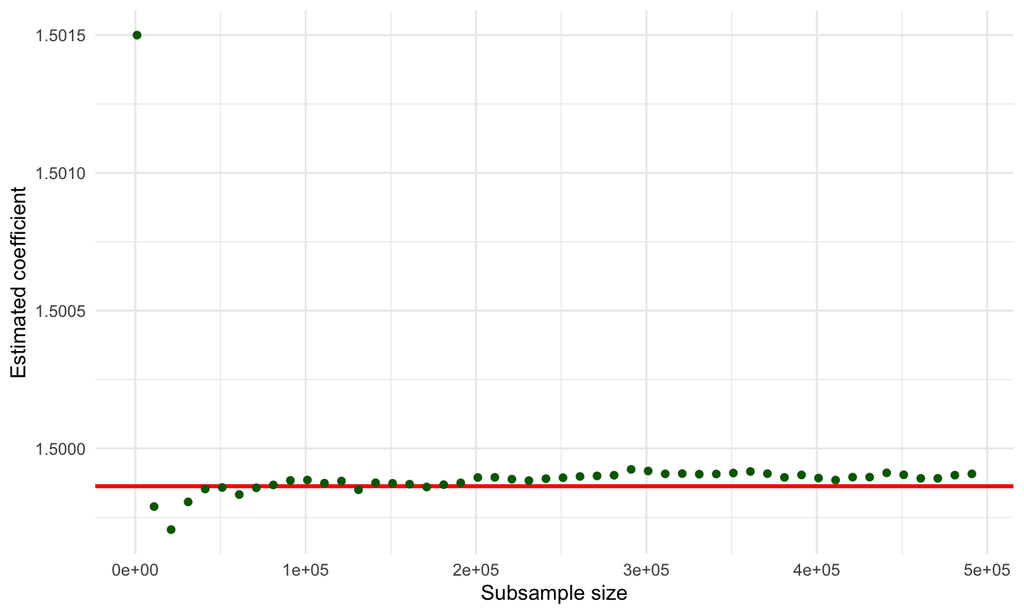

```r
ggplot(plotdata, aes(x = subs_size, y = beta1)) +
     geom_hline(yintercept = ols_res,
                color = "red",
                size = 1) +
     geom_point(color="darkgreen") +

     theme_minimal() +
     ylab("Estimated coefficient") +
     xlab("Subsample size")
```

## Cleaning and Transformation

## Typical tasks (independent of data set size)

- Normalize/standardize.
- Code additional variables (indicators, strings to categorical, etc.).
- Remove, add covariates.
- Merge data sets.
- Set data types.

## Typical workflow

1. Import raw data.
2. Clean/transform.
3. Store for analysis.
   - Write to file.
   - Write to database.

## Bottlenecks

- RAM:
  - Raw data does not fit into memory.
  - Transformations enlarge RAM allocation (copying).
- Mass Storage: Reading/Writing
- CPU: Parsing (data types)

## Data Preparation with `ff`

## Set up

The following examples are based on Walkowiak (2016), Chapter 3.

```r
## SET UP ------------------------

#Set working directory to the data and airline_id files.
# setwd("materials/code_book/B05396_Ch03_Code")
system("mkdir ffdf")
options(fftempdir = "ffdf")

# load packages
library(ff)
library(ffbase)
library(pryr)

# fix vars
FLIGHTS_DATA <- "../code_book/B05396_Ch03_Code/flights_sep_oct15.txt"
AIRLINES_DATA <- "../code_book/B05396_Ch03_Code/airline_id.csv"
```

## Data import

```r
# DATA IMPORT ------------------

# 1. Upload flights_sep_oct15.txt and airline_id.csv files from flat files.

system.time(flights.ff <- read.table.ffdf(file=FLIGHTS_DATA,
                                          sep=",",
                                          VERBOSE=TRUE,
                                          header=TRUE,
                                          next.rows=100000,
                                          colClasses=NA))
```

```
## read.table.ffdf 1..100000 (100000)  csv-read=1.095sec ffdf-write=0.216sec
## read.table.ffdf 100001..200000 (100000)  csv-read=1.658sec ffdf-write=0.229sec
## read.table.ffdf 200001..300000 (100000)  csv-read=1.646sec ffdf-write=0.137sec
## read.table.ffdf 300001..400000 (100000)  csv-read=1.739sec ffdf-write=0.235sec
## read.table.ffdf 400001..500000 (100000)  csv-read=1.609sec ffdf-write=0.14sec
## read.table.ffdf 500001..600000 (100000)  csv-read=1.944sec ffdf-write=0.126sec
## read.table.ffdf 600001..700000 (100000)  csv-read=1.703sec ffdf-write=0.136sec
## read.table.ffdf 700001..800000 (100000)  csv-read=1.84sec ffdf-write=0.13sec
## read.table.ffdf 800001..900000 (100000)  csv-read=1.923sec ffdf-write=0.25sec
## read.table.ffdf 900001..951111 (51111)  csv-read=1.053sec ffdf-write=0.111sec
##  csv-read=16.21sec  ffdf-write=1.71sec  TOTAL=17.92sec
```

```
##    user  system elapsed
##  12.124   1.115  17.926
```

```r
airlines.ff <- read.csv.ffdf(file= AIRLINES_DATA,
                             VERBOSE=TRUE,
                             header=TRUE,
                             next.rows=100000,
                             colClasses=NA)
```

```
## read.table.ffdf 1..1607 (1607)  csv-read=0.013sec ffdf-write=0.008sec
##  csv-read=0.013sec  ffdf-write=0.008sec  TOTAL=0.021sec
```

```r
# check memory used
mem_used()
```

```
## 1.12 GB
```

## Comparison with `read.table`

```r
##Using read.table()
system.time(flights.table <- read.table(FLIGHTS_DATA,
                                        sep=",",
                                        header=TRUE))
```

```
##    user  system elapsed
##   9.335   0.566  11.220
```

```r
gc()
```

```
##             used   (Mb) gc trigger   (Mb) limit (Mb)  max used   (Mb)
## Ncells   1264337   67.6    1971988  105.4         NA   1971988  105.4
## Vcells 144276910 1100.8  256251554 1955.1      16384 256177679 1954.5
```

```r
system.time(airlines.table <- read.csv(AIRLINES_DATA,
                                       header = TRUE))
```

```
##    user  system elapsed
##   0.006   0.001   0.008
```

```r
# check memory used
mem_used()
```

```
## 1.23 GB
```

## Inspect imported files

```r
# 2. Inspect the ffdf objects.
## For flights.ff object:
class(flights.ff)
```

```
## [1] "ffdf"
```

```r
dim(flights.ff)
```

```
## [1] 951111     28
```

```r
## For airlines.ff object:
class(airlines.ff)
```

```
## [1] "ffdf"
```

```r
dim(airlines.ff)
```

```
## [1] 1607    2
```

## Data cleaning and transformation

Goal: merge airline data to flights data

```r
# step 1:
## Rename "Code" variable from airlines.ff to "AIRLINE_ID" and "Description" into "AIRLINE_NM".
names(airlines.ff) <- c("AIRLINE_ID", "AIRLINE_NM")
names(airlines.ff)
```

```
## [1] "AIRLINE_ID" "AIRLINE_NM"
```

```r
str(airlines.ff[1:20,])
```

```
## 'data.frame':    20 obs. of  2 variables:
##  $ AIRLINE_ID: int  19031 19032 19033 19034 19035 19036 19037 19038 19039 19040 ...
##  $ AIRLINE_NM: Factor w/ 1607 levels "40-Mile Air: Q5",..: 945 1025 503 721 64 725 1194 99 1395 276 ...
```

## Data cleaning and transformation

Goal: merge airline data to flights data

```r
# merge of ffdf objects
mem_change(flights.data.ff <- merge.ffdf(flights.ff, airlines.ff, by="AIRLINE_ID"))
```

```
## 658 kB
```

```r
#The new object is only 551.2 Kb in size
class(flights.data.ff)
```

```
## [1] "ffdf"
```

```r
dim(flights.data.ff)
```

```
## [1] 951111     29
```

```r
dimnames.ffdf(flights.data.ff)
```

```
## [[1]]
## NULL
##
## [[2]]
##  [1] "YEAR"              "MONTH"             "DAY_OF_MONTH"      "DAY_OF_WEEK"
##  [5] "FL_DATE"           "UNIQUE_CARRIER"    "AIRLINE_ID"        "TAIL_NUM"
##  [9] "FL_NUM"            "ORIGIN_AIRPORT_ID" "ORIGIN"            "ORIGIN_CITY_NAME"
## [13] "ORIGIN_STATE_NM"   "ORIGIN_WAC"        "DEST_AIRPORT_ID"   "DEST"
## [17] "DEST_CITY_NAME"    "DEST_STATE_NM"     "DEST_WAC"          "DEP_TIME"
## [21] "DEP_DELAY"         "ARR_TIME"          "ARR_DELAY"         "CANCELLED"
## [25] "CANCELLATION_CODE" "DIVERTED"          "AIR_TIME"          "DISTANCE"
## [29] "AIRLINE_NM"
```

## Inspect difference to in-memory operation

```r
##For flights.table:
names(airlines.table) <- c("AIRLINE_ID", "AIRLINE_NM")
names(airlines.table)
```

```
## [1] "AIRLINE_ID" "AIRLINE_NM"
```

```r
str(airlines.table[1:20,])
```

```
## 'data.frame':    20 obs. of  2 variables:
##  $ AIRLINE_ID: int  19031 19032 19033 19034 19035 19036 19037 19038 19039 19040 ...
##  $ AIRLINE_NM: Factor w/ 1607 levels "40-Mile Air: Q5",..: 945 1025 503 721 64 725 1194 99 1395 276 ...
```

```r
# check memory usage of merge in RAM
mem_change(flights.data.table <- merge(flights.table,
                                       airlines.table,
                                       by="AIRLINE_ID"))
```

```
## 118 MB
```

```r
#The new object is already 105.7 Mb in size
#A rapid spike in RAM use when processing
```

## Type conversion: ff factor

```r
# Inspect the current variable
table.ff(flights.data.ff$DAY_OF_WEEK)
```

```
##
##      1      2      3      4      5      6      7
## 131267 143057 145057 148544 148159 112239 122788
```

```r
head(flights.data.ff$DAY_OF_WEEK)
```

```
## [1] 1 1 1 1 1 1
```

```r
# Convert numeric ff DAY_OF_WEEK vector to a ff factor:
flights.data.ff$WEEKDAY <- cut.ff(flights.data.ff$DAY_OF_WEEK,
                                   breaks = 7,
                                   labels = c("Monday", "Tuesday",
                                              "Wednesday", "Thursday",
                                              "Friday", "Saturday",
                                              "Sunday"))
# inspect the result
head(flights.data.ff$WEEKDAY)
```

```
## [1] Monday Monday Monday Monday Monday Monday
## Levels: Monday Tuesday Wednesday Thursday Friday Saturday Sunday
```

```r
table.ff(flights.data.ff$WEEKDAY)
```

```
##
##    Monday   Tuesday Wednesday  Thursday    Friday  Saturday    Sunday
##    131267    143057    145057    148544    148159    112239    122788
```

## Subsetting

```r
mem_used()
```

```
## 1.34 GB
```

```r
# Subset the ffdf object flights.data.ff:
subs1.ff <- subset.ffdf(flights.data.ff, CANCELLED == 1,
                        select = c(FL_DATE, AIRLINE_ID,
                                   ORIGIN_CITY_NAME,
                                   ORIGIN_STATE_NM,
                                   DEST_CITY_NAME,
                                   DEST_STATE_NM,
                                   CANCELLATION_CODE))

dim(subs1.ff)
```

```
## [1] 4529    7
```

```r
mem_used()
```

```
## 1.34 GB
```

## Save to ffdf-files

(For further processing with `ff`)

```r
# Save a newly created ffdf object to a data file:

save.ffdf(subs1.ff) #7 files (one for each column) created in the ffdb directory
```

## Load ffdf-files

```r
# Loading previously saved ffdf files:
rm(subs1.ff)
gc()
```

```
##             used   (Mb) gc trigger   (Mb) limit (Mb)  max used   (Mb)
## Ncells   1286757   68.8    4256192  227.4         NA   3163814  169.0
## Vcells 159040068 1213.4  256251554 1955.1      16384 256177679 1954.5
```

```r
load.ffdf("ffdb")
str(subs1.ff)
```

```
## List of 3
##  $ virtual: 'data.frame':    7 obs. of  7 variables:
##  .. $ VirtualVmode     : chr  "integer" "integer" "integer" "integer" ...
##  .. $ AsIs             : logi  FALSE FALSE FALSE FALSE FALSE FALSE ...
##  .. $ VirtualIsMatrix  : logi  FALSE FALSE FALSE FALSE FALSE FALSE ...
##  .. $ PhysicalIsMatrix : logi  FALSE FALSE FALSE FALSE FALSE FALSE ...
##  .. $ PhysicalElementNo: int  1 2 3 4 5 6 7
##  .. $ PhysicalFirstCol : int  1 1 1 1 1 1 1
##  .. $ PhysicalLastCol  : int  1 1 1 1 1 1 1
##  .. - attr(*, "Dim")= int  4529 7
##  .. - attr(*, "Dimorder")= int  1 2
##  $ physical: List of 7
##  .. $ FL_DATE          : list()
##  ..  ..- attr(*, "physical")=Class 'ff_pointer' <externalptr>
##  ..  .. ..- attr(*, "vmode")= chr "integer"
##  ..  .. ..- attr(*, "maxlength")= int 4529
##  ..  .. ..- attr(*, "pattern")= chr "ffdf"
##  ..  .. ..- attr(*, "filename")= chr "/Users/umatter/Dropbox/Teaching/HSG/BigData/BigData/materials/slides/ffdb/subs1.ff$FL_DATE.ff"
##  ..  .. ..- attr(*, "pagesize")= int 65536
##  ..  .. ..- attr(*, "finalizer")= chr "close"
##  ..  .. ..- attr(*, "finonexit")= logi TRUE
##  ..  .. ..- attr(*, "readonly")= logi FALSE
##  ..  .. ..- attr(*, "caching")= chr "mmnoflush"
##  ..  ..- attr(*, "virtual")= list()
##  ..  .. ..- attr(*, "Length")= int 4529
##  ..  .. ..- attr(*, "Symmetric")= logi FALSE
##  ..  .. ..- attr(*, "Levels")= chr [1:61] "2015-09-01" "2015-09-02" "2015-09-03" "2015-09-04" ...
##  ..  .. ..- attr(*, "ramclass")= chr "factor"
##  .. .. - attr(*, "class") =  chr [1:2] "ff_vector" "ff"
##  .. $ AIRLINE_ID       : list()
##  ..  ..- attr(*, "physical")=Class 'ff_pointer' <externalptr>
##  ..  .. ..- attr(*, "vmode")= chr "integer"
##  ..  .. ..- attr(*, "maxlength")= int 4529
##  ..  .. ..- attr(*, "pattern")= chr "ffdf"
##  ..  .. ..- attr(*, "filename")= chr "/Users/umatter/Dropbox/Teaching/HSG/BigData/BigData/materials/slides/ffdb/subs1.ff$AIRLINE_ID.ff"
##  ..  .. ..- attr(*, "pagesize")= int 65536
##  ..  .. ..- attr(*, "finalizer")= chr "close"
##  ..  .. ..- attr(*, "finonexit")= logi TRUE
##  ..  .. ..- attr(*, "readonly")= logi FALSE
##  ..  .. ..- attr(*, "caching")= chr "mmnoflush"
```

[output cut: 78 more lines]

```
##  ..  .. ..- attr(*, "pagesize")= int 65536
##  ..  .. ..- attr(*, "finalizer")= chr "close"
##  ..  .. ..- attr(*, "finonexit")= logi TRUE
##  ..  .. ..- attr(*, "readonly")= logi FALSE
##  ..  .. ..- attr(*, "caching")= chr "mmnoflush"
##  ..  ..- attr(*, "virtual")= list()
##  ..  .. ..- attr(*, "Length")= int 4529
##  ..  .. ..- attr(*, "Symmetric")= logi FALSE
##  ..  .. ..- attr(*, "Levels")= chr [1:4] "" "A" "B" "C"
##  ..  .. ..- attr(*, "ramclass")= chr "factor"
##  .. .. - attr(*, "class") =  chr [1:2] "ff_vector" "ff"
##  $ row.names:  NULL
## - attributes: List of 2
##  .. $ names: chr [1:2] "virtual" "physical"
##  .. $ class: chr "ffdf"
```

```r
dim(subs1.ff)
```

```
## [1] 4529    7
```

```r
dimnames(subs1.ff)
```

```
## [[1]]
## NULL
##
## [[2]]
## [1] "FL_DATE"           "AIRLINE_ID"        "ORIGIN_CITY_NAME"  "ORIGIN_STATE_NM"
## [5] "DEST_CITY_NAME"    "DEST_STATE_NM"     "CANCELLATION_CODE"
```

## Export to CSV

```r
#  Export subs1.ff into CSV and TXT files:
write.csv.ffdf(subs1.ff, "subset1.csv")
```

## References

Dhillon, Paramveer, Yichao Lu, Dean P. Foster, and Lyle Ungar. 2013. “New Subsampling Algorithms for Fast Least Squares Regression.” In *Advances in Neural Information Processing Systems 26*, 360–68.

Walkowiak, Simkon. 2016. *Big Data Analytics with R*. Birmingham, UK: PACKT Publishing.